# Healthcare Digest

**Week of October 5, 2026**Market data through: October 2, 2026Narrative created: October 5, 2026

Weekly review of healthcare services, technology, distribution, and diagnostic company performance, changes, earnings activity, and strategy narrative.

## In the News

### Executive Summary

- **The final 2027 Medicare Advantage landscape resolves the benefit-retrenchment question but reveals a two-speed market.** National plan availability and average premiums appear stable, while major carriers are pruning underperforming products and shifting toward HMOs and special-needs plans.
- **Federal price-transparency policy moved from data volume toward data usability and accountability.** New requirements reduce redundant files but add utilization context, provider-taxonomy logic and senior-official attestations, changing the opportunity for transparency-data vendors.
- **CMS finalized international reference pricing for Part B drugs, but at a fraction of the proposed economic scale.** GLOBE remains operationally complex for selected providers while targeting less than 1% of relevant Original Medicare Part B drug spending.
- **OIG identified a broader Medicare managed-care screening failure.** Plans paid $72 million for services associated with revoked or otherwise problematic providers, extending the integrity gap from individual suppliers into ownership, pharmacy and list-management controls.
- **Overall environment: modestly deteriorated for MA plan continuity and payment integrity; improved for transparency-data quality; broadly unchanged for near-term provider drug economics.**

### 1. Aggregate MA stability conceals targeted carrier retrenchment

**What happened**

The September 28 Medicare Advantage landscape resolves the preliminary plan-design signals discussed earlier in September. CMS projects that the weighted average monthly MA premium will decline 16.5%, from $14.37 in 2026 to $12.00 in 2027. The number of available plans is expected to remain nearly flat—5,532 versus 5,553—while more than 99% of beneficiaries retain access to at least one MA plan and 97% have at least 10 choices. CMS projects 34 million enrollees, or 47.4% of Medicare beneficiaries. ([CMS, “Medicare Advantage and Medicare Prescription Drug Programs Expected to Remain Stable in 2027,” September 28, 2026](https://www.cms.gov/newsroom/press-releases/medicare-advantage-medicare-prescription-drug-programs-expected-remain-stable-2027)). ([cms.gov](https://www.cms.gov/newsroom/press-releases/medicare-advantage-medicare-prescription-drug-programs-expected-remain-stable-2027?utm_source=openai))

The national totals obscure substantial portfolio rotation. Analysis of the CMS files found heavy product reductions by UnitedHealthcare and Humana offset partly by continued growth in special-needs plans. UnitedHealthcare separately confirmed that it is discontinuing plans and changing service areas effective January 1, with nonrenewal notices dated October 2. ([Healthcare Dive, “Here’s how much insurers are cutting Medicare Advantage plans for 2027,” September 29, 2026](https://www.healthcaredive.com/news/medicare-advantage-cuts-2027-cms-landscape/831563/); [UnitedHealthcare, “2027 Medicare Advantage service area changes,” October 1, 2026](https://ams-gateway.uhcprovider.com/en/resource-library/news/2026/medadv-2027-service-area-changes.html)). ([healthcaredive.com](https://www.healthcaredive.com/news/medicare-advantage-cuts-2027-cms-landscape/831563/?trk=article-ssr-frontend-pulse_little-text-block&utm_source=openai))

**Implication**

The prior thesis is now more precise: MA margin repair is being pursued through local product selection, network structure and benefit design rather than broad premium increases or a nationwide withdrawal. Average premiums therefore overstate stability because they do not capture changes in cost sharing, supplemental allowances, provider access or forced member switching.

The directional benefit for carriers is improved 2027 risk selection and reduced exposure to structurally unprofitable markets. Providers face greater referral and contracting concentration as enrollment shifts toward narrower HMO and SNP products. Distribution, member-comparison and provider-directory platforms should expect elevated demand during open enrollment, particularly where nonrenewals require beneficiaries to choose replacement coverage.

**Watch next**

Enrollment migration during the October 15–December 7 open-enrollment period, especially whether product exits move members toward competitors or into carriers’ narrower successor plans.

### 2. Transparency in Coverage shifts from file production to governed data infrastructure

**What happened**

On October 5, the Departments of HHS, Labor and Treasury finalized revisions to the Transparency in Coverage rules. Plans and issuers will report one in-network-rate file per provider network rather than per plan, move in-network and out-of-network files from monthly to quarterly publication, and exclude clinically implausible provider-service combinations using the same taxonomy logic employed in claims adjudication.

The rules also add provider-taxonomy and utilization files, lower the out-of-network reporting threshold from 20 claims to 11, require standardized file-location information and mandate attestations that the disclosures are complete and accurate. Each file must identify the CEO, president or designated senior official responsible for oversight. The departments estimate approximately $174.5 million of annual net savings for plans and issuers beginning in the second implementation year. ([CMS, “Transparency in Coverage Final Rules,” October 5, 2026](https://www.cms.gov/newsroom/fact-sheets/transparency-coverage-final-rules-cms-9882-f)). ([cms.gov](https://www.cms.gov/newsroom/fact-sheets/transparency-coverage-final-rules-cms-9882-f))

The in-network and out-of-network amendments apply five months after Federal Register publication; the new taxonomy, utilization and location files apply after 11 months. Telephone access to personalized cost-sharing information applies for plan years beginning January 1, 2027. Prescription-drug file development begins in November 2026, with publication expected to start in December 2027. ([CMS, “New Regulations Make It Easier to Find, Compare, and Report Healthcare Pricing and Coverage Information,” October 5, 2026](https://www.cms.gov/newsroom/press-releases/new-regulations-make-it-easier-find-compare-report-healthcare-pricing-coverage-information)). ([cms.gov](https://www.cms.gov/newsroom/press-releases/new-regulations-make-it-easier-find-compare-report-healthcare-pricing-coverage-information))

**Implication**

The opportunity is moving away from brute-force hosting and ingestion of enormous duplicate files. Competitive advantage will increasingly come from provider identity resolution, taxonomy mapping, contractual-rate normalization, utilization context and defensible data-quality controls.

For plans, quarterly reporting and network-level files reduce infrastructure expense, but senior-official attestation turns data accuracy into an enterprise compliance issue. For employers and providers, more usable out-of-network and utilization data should improve benchmarking and contract analysis. Vendors dependent primarily on storage volume face pressure; platforms that connect transparency data to claims, network design and contracting gain relevance.

**Watch next**

Technical guidance specifying the single machine-readable format and how regulators evaluate taxonomy exclusions, utilization completeness and executive attestations.

### 3. GLOBE survives as a mandatory model but loses most of its proposed economic reach

**What happened**

CMS finalized the Global Benchmark for Efficient Drug Pricing Model, effective November 30. The mandatory manufacturer model begins January 1, 2027; international-benchmark rebates and reduced beneficiary coinsurance start April 1 and continue through March 31, 2032, with reconciliation extending into 2034. Selected geographic areas will represent approximately 25% of Original Medicare Part B beneficiaries. ([CMS Innovation Center, “GLOBE Model,” updated October 2, 2026](https://www.cms.gov/priorities/innovation/innovation-models/globe)). ([cms.gov](https://www.cms.gov/priorities/innovation/innovation-models/globe?utm_source=openai))

The final model is materially narrower than proposed. CMS estimates that covered utilization will represent less than 1% of non-dual, non-340B Original Medicare Part B drug spending. Estimated annualized Part B savings fell from $2.3 billion in the proposal to $80 million in the final rule; cumulative estimates include $298 million for Original Medicare, $288 million from subsequent MA benchmark effects and $39 million for Medicaid. CMS estimates $177 million of beneficiary premium and coinsurance savings. The standard provider add-on remains 6% of average sales price for most drugs. ([Federal Register, “Global Benchmark for Efficient Drug Pricing Model,” October 2, 2026](https://www.govinfo.gov/content/pkg/FR-2026-10-02/html/2026-20281.htm)). ([govinfo.gov](https://www.govinfo.gov/content/pkg/FR-2026-10-02/html/2026-20281.htm))

**Implication**

GLOBE is not a broad reset of oncology or specialty-infusion economics. Its immediate burden is operational: selected providers must identify eligible beneficiaries and drugs, collect the correct reduced coinsurance and reconcile geographically variable claim treatment. Because Medicare adjusts its payment when beneficiary coinsurance falls, the model does not directly reduce the allowed provider payment.

The longer-term payer effect is small but directionally negative for MA rebates: lower Original Medicare spending flows into benchmarks beginning with 2028 rate setting. Technology demand should concentrate in eligibility, charge-capture and patient-responsibility workflows rather than widespread drug-cost management.

**Watch next**

CMS’s selected geographic areas and initial drug list, which will determine which oncology practices, hospital outpatient departments and billing platforms must implement the model.

### 4. OIG expands the Medicare preclusion gap into ownership and pharmacy controls

**What happened**

Prior audits showed that suppliers removed from Original Medicare could continue billing MA plans. OIG now reports that MA organizations and Part D plans paid $72 million during 2022–2024 for services associated with 249 of 1,017 revoked provider identifiers reviewed.

OIG attributed the payments to delays and errors in CMS’s Preclusion List, failure to list some organizations whose owners were excluded or convicted of felonies, and regulations that do not subject dispensing-only pharmacies to preclusion. OIG issued no formal recommendations but said the findings could support future regulation or guidance. (HHS-OIG, “Medicare Advantage Organizations and Prescription Drug Plans Paid $72 Million During a 3-Year Period for Services Associated With Excluded Providers or Individuals Convicted of Certain Felonies,” October 1, 2026). (oig.hhs.gov)

**Implication**

NPI-level screening is insufficient when exclusion risk can sit with an owner, affiliated organization or dispensing pharmacy. Plans need entity-resolution controls that connect enrollment status, ownership, felony and exclusion data across Parts A, B, C and D.

The direct $72 million finding is modest relative to total managed-care spending, but the control failure creates recovery, audit and reputational exposure. It strengthens demand for continuously refreshed provider-master data and prepayment screening rather than periodic list checks.

**Watch next**

Whether CMS expands the Preclusion List’s ownership and pharmacy scope or places explicit screening obligations on MA and Part D sponsors.

### What I'm Watching Next

- **October 6, 2026:** Scheduled Federal Register publication of the Transparency in Coverage final rules. ([Federal Register, public-inspection notice, October 5, 2026](https://www.federalregister.gov/public-inspection/2026-20447/transparency-in-coverage)). ([federalregister.gov](https://www.federalregister.gov/public-inspection/2026-20447/transparency-in-coverage))
- **October 15, 2026:** Medicare open enrollment begins, providing the first market test of 2027 MA nonrenewals and product redesign.
- **October 21, 2026:** Comment period closes on preliminary 2027 Clinical Laboratory Fee Schedule rates. ([CMS, September 21, 2026](https://www.cms.gov/newsroom/fact-sheets/preliminary-calendar-year-cy-2027-medicare-clinical-laboratory-fee-schedule-payment-rates)). ([cms.gov](https://www.cms.gov/newsroom/press-releases/cms-announces-new-preliminary-medicare-payment-rates-laboratory-services-saving-taxpayers-estimated?utm_source=openai))

### Bottom Line

The week’s most important change is the resolution of the 2027 MA landscape: national access remains broad, but carrier-level product pruning confirms that margin repair is occurring through localized exits, narrower designs and member migration. MA plan continuity requires the closest attention. Open enrollment beginning October 15 is the next event most likely to reveal whether retrenchment improves payer mix without materially weakening competitive position.

## Notable Changes

Comparison with the final report dated September 28, 2026 (market data through September 25, 2026).

### Sectors

#### Top-three comparison

| Entity | Previous | Current | Change | Current return |
| --- | --- | --- | --- | --- |
| Precision Diagnostics | #1 | #1 | — 0 | +121.5% |
| Value-Based Care | #2 | #2 | — 0 | +53.6% |
| Inpatient Non-Acute Providers | #3 | #3 | — 0 | +48.0% |

### Stocks

#### Top-three comparison

| Entity | Previous | Current | Change | Current return |
| --- | --- | --- | --- | --- |
| 10x Genomics (TXG) | #1 | #1 | — 0 | +633.3% |
| PACS Group (PACS) | #3 | #2 | ↑ 1 | +213.0% |
| Agilon Health (AGL) | #2 | #3 | ↓ 1 | +197.8% |

#### Largest rank changes

| Entity | Previous | Current | Change | Current return |
| --- | --- | --- | --- | --- |
| PacBio (PACB) | #22 | #12 | ↑ 10 | +70.5% |
| HealthEquity (HQY) | #56 | #43 | ↑ 13 | +1.6% |
| Tempus AI (TEM) | #41 | #58 | ↓ 17 | -16.4% |

### Subcategory movement since the previous report

| Subcategory | Move | Last Report, 12m Ret | Current Report, 12m Ret |
| --- | --- | --- | --- |
| Pharma Distribution | +2.8% | +18.0% | +23.1% |
| Health IT and Data | +2.5% | -37.3% | -38.8% |
| Value-Based Care | +1.9% | +51.7% | +53.6% |
| Outpatient and Home Providers | +0.3% | +35.8% | +35.5% |
| Digital Health, Specialty, Benefits | +0.1% | -2.0% | -0.4% |
| Precision Diagnostics | -0.7% | +130.9% | +121.5% |
| Inpatient Non-Acute Providers | -0.8% | +46.2% | +48.0% |
| Payers | -1.5% | +16.8% | +8.5% |
| Health System Providers | -1.8% | +6.5% | +2.5% |
| Health Care Real Estate | -2.1% | +26.2% | +23.4% |

### Largest company moves

| Direction | Company | Ticker | Move |
| --- | --- | --- | --- |
| Gain | PacBio | PACB | +56.8% |
| Gain | 10x Genomics | TXG | +9.1% |
| Gain | BrightSpring Health Services | BTSG | +6.5% |
| Decline | BillionToOne | BLLN | -14.0% |
| Decline | Tempus AI | TEM | -9.9% |
| Decline | P3 Health | PIII | -9.8% |

## Subcategory Performance

| Subcategory | Companies | Market cap | 3m Return | 12m Return | 24m Return |
| --- | --- | --- | --- | --- | --- |
| Payers | 10 | $769.8B | -11.6% | +8.5% | -13.6% |
| Health System Providers | 5 | $119.8B | +8.3% | +2.5% | +14.9% |
| Inpatient Non-Acute Providers | 4 | $31.4B | +3.2% | +48.0% | +13.9% |
| Health Care Real Estate | 8 | $266.4B | -6.0% | +23.4% | +58.6% |
| Value-Based Care | 5 | $7.2B | -26.4% | +53.6% | -6.5% |
| Outpatient and Home Providers | 11 | $64.8B | -7.4% | +35.5% | +69.0% |
| Digital Health, Specialty, Benefits | 9 | $25.4B | -9.1% | -0.4% | +32.8% |
| Health IT and Data | 11 | $470.6B | +6.6% | -38.8% | -9.5% |
| Pharma Distribution | 5 | $222.6B | +6.2% | +23.1% | +74.6% |
| Precision Diagnostics | 12 | $168.6B | +28.5% | +121.5% | +194.4% |

Subcategory returns use the most recently saved market capitalizations as weights.

## Stock Performance vs. SPY

The same selected stocks appear in every chart. Each line is labeled at the right with its ticker and return for the displayed window.

### Last 6 months

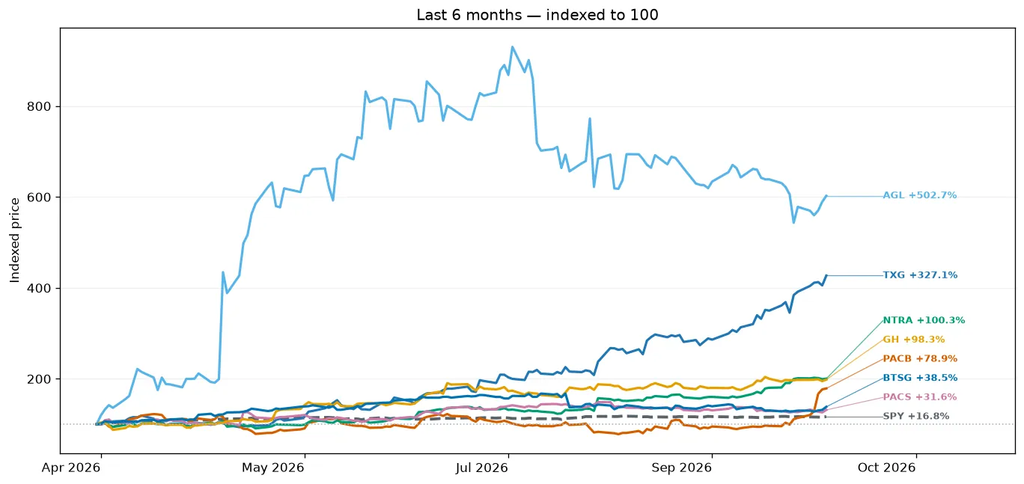

### Last 12 months

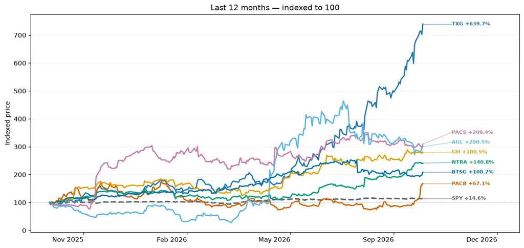

### Last 24 months

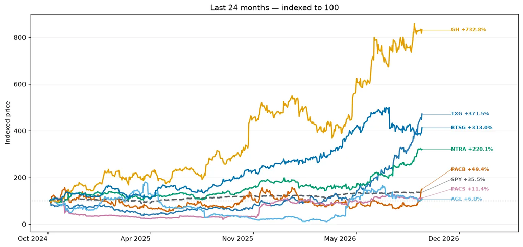

## Current Top Stocks

### Last 3 months

| Rank | Company | Ticker | Market cap | Return |
| --- | --- | --- | --- | --- |
| 1 | 10x Genomics | TXG | $6.1B | +139.7% |
| 2 | PacBio | PACB | $447.3M | +51.2% |
| 3 | Natera | NTRA | $39.4B | +46.9% |
| 4 | Illumina | ILMN | $30.7B | +44.7% |
| 5 | Veeva Systems | VEEV | $33.1B | +41.8% |

### Last 12 months

| Rank | Company | Ticker | Market cap | Return |
| --- | --- | --- | --- | --- |
| 1 | 10x Genomics | TXG | $6.1B | +633.3% |
| 2 | PACS Group | PACS | $7.3B | +213.0% |
| 3 | Agilon Health | AGL | $2.1B | +197.8% |
| 4 | Guardant Health | GH | $21.4B | +182.9% |
| 5 | Illumina | ILMN | $30.7B | +167.4% |

### Last 24 months

| Rank | Company | Ticker | Market cap | Return |
| --- | --- | --- | --- | --- |
| 1 | Guardant Health | GH | $21.4B | +702.3% |
| 2 | 10x Genomics | TXG | $6.1B | +367.0% |
| 3 | BrightSpring Health Services | BTSG | $12.4B | +308.2% |
| 4 | Natera | NTRA | $39.4B | +216.0% |
| 5 | Aveanna Healthcare | AVAH | $2.0B | +177.9% |

## Companies by Subcategory

### PayersLast 3m: -11.6%

| Company | Ticker | Market cap | 3m Return | 12m Return | 24m Return |
| --- | --- | --- | --- | --- | --- |
| UnitedHealth | UNH | $380.1B | -12.6% | +3.2% | -37.1% |
| CVS Health | CVS | $135.1B | -17.4% | +11.6% | +33.9% |
| Humana | HUM | $43.7B | -2.1% | +36.9% | +61.8% |
| Oscar Health | OSCR | $9.4B | -3.9% | +42.8% | +53.6% |
| Molina Healthcare | MOH | $10.2B | -17.5% | -6.2% | -42.7% |
| Cigna | CI | $73.7B | -6.0% | -13.0% | -20.8% |
| Elevance | ELV | $81.5B | -7.5% | +10.3% | -21.5% |
| Clover Health | CLOV | $2.2B | -16.7% | +69.1% | +8.4% |
| Centene | CNC | $30.7B | -7.2% | +62.8% | -12.6% |
| Alignment Health | ALHC | $3.1B | -66.6% | -52.2% | -27.3% |

### Health System ProvidersLast 3m: +8.3%

| Company | Ticker | Market cap | 3m Return | 12m Return | 24m Return |
| --- | --- | --- | --- | --- | --- |
| HCA Healthcare | HCA | $87.2B | +3.9% | -0.7% | +8.3% |
| Tenet Health | THC | $20.5B | +26.9% | +27.4% | +65.2% |
| Universal Health Services | UHS | $10.2B | +11.0% | -15.2% | -18.5% |
| Community Health Systems | CYH | $417.4M | -30.3% | -12.8% | -51.8% |
| Ardent Health Partners | ARDT | $1.5B | -3.9% | -26.2% | -42.5% |

### Inpatient Non-Acute ProvidersLast 3m: +3.2%

| Company | Ticker | Market cap | 3m Return | 12m Return | 24m Return |
| --- | --- | --- | --- | --- | --- |
| The Ensign Group | ENSG | $10.4B | +2.1% | -2.1% | +19.1% |
| Acadia Healthcare | ACHC | $2.8B | -12.1% | +3.4% | -49.7% |
| Encompass Health | EHC | $11.0B | +12.5% | -2.8% | +26.8% |
| PACS Group | PACS | $7.3B | -3.7% | +213.0% | +11.3% |

### Health Care Real EstateLast 3m: -6.0%

| Company | Ticker | Market cap | 3m Return | 12m Return | 24m Return |
| --- | --- | --- | --- | --- | --- |
| Healthpeak properties | DOC | $15.1B | -11.0% | +0.6% | -11.9% |
| Ventas, Inc | VTR | $48.0B | -9.2% | +20.4% | +34.4% |
| Medical Properties Trust | MPT | $2.8B | -28.8% | — | — |
| National Health Investors | NHI | $3.7B | -15.2% | -16.3% | -19.2% |
| Omega Healthcare Investors | OHI | $15.1B | -7.4% | +11.1% | +16.2% |
| Welltower | WELL | $166.9B | -3.5% | +30.1% | +81.4% |
| CareTrust REIT | CTRE | $9.6B | -13.1% | +2.3% | +19.5% |
| Sabra Health Care REIT | SBRA | $5.3B | -5.0% | +5.6% | +6.6% |

### Value-Based CareLast 3m: -26.4%

| Company | Ticker | Market cap | 3m Return | 12m Return | 24m Return |
| --- | --- | --- | --- | --- | --- |
| Privia Health Group | PRVA | $3.0B | -25.8% | -15.7% | +15.4% |
| Astrana Health | ASTH | $1.8B | -27.0% | +24.8% | -40.1% |
| Agilon Health | AGL | $2.1B | -24.2% | +197.8% | +4.8% |
| Evolent Health | EVH | $347.6M | -39.4% | -58.0% | -86.9% |
| P3 Health | PIII | $32.7M | -44.1% | -26.5% | -66.3% |

### Outpatient and Home ProvidersLast 3m: -7.4%

| Company | Ticker | Market cap | 3m Return | 12m Return | 24m Return |
| --- | --- | --- | --- | --- | --- |
| Davita | DVA | $15.4B | -23.9% | +36.2% | +11.2% |
| Fresenius | FMS | $13.8B | -5.4% | -16.8% | +7.5% |
| Surgery Partners | SGRY | $2.0B | -22.7% | -37.0% | -57.3% |
| Option Care Health | OPCH | $3.4B | +3.4% | -17.7% | -22.3% |
| Lifestance Health | LFST | $4.0B | +5.0% | +114.7% | +71.2% |
| Chemed (Vitas) | CHE | $7.1B | +3.6% | +14.4% | -12.7% |
| Addus HomeCare | ADUS | $2.1B | +5.8% | -3.1% | -11.9% |
| Pennant Group | PNTG | $1.3B | +1.9% | +51.7% | +18.9% |
| US Physical Therapy | USPH | $1.2B | +15.7% | -5.9% | +3.3% |
| BrightSpring Health Services | BTSG | $12.4B | -12.7% | +112.4% | +308.2% |
| Aveanna Healthcare | AVAH | $2.0B | +38.4% | +45.9% | +177.9% |

### Digital Health, Specialty, BenefitsLast 3m: -9.1%

| Company | Ticker | Market cap | 3m Return | 12m Return | 24m Return |
| --- | --- | --- | --- | --- | --- |
| Teladoc | TDOC | $1.2B | -40.0% | -38.7% | -38.9% |
| Amwell | AMWL | $179.6M | +33.9% | +95.7% | +32.4% |
| Hims & Hers | HIMS | $6.4B | -21.2% | -44.8% | +64.2% |
| LifeMD | LFMD | $169.3M | -43.7% | -60.7% | -43.3% |
| Omada Health | OMDA | $1.2B | -9.0% | -6.9% | — |
| GoodRx | GDRX | $1.0B | +7.5% | -27.6% | -53.7% |
| Progyny | PGNY | $2.5B | -16.5% | +22.5% | +54.8% |
| Concentra Group | CON | $4.0B | +11.7% | +71.8% | +70.0% |
| HealthEquity | HQY | $8.8B | -5.5% | +1.6% | +8.4% |

### Health IT and DataLast 3m: +6.6%

| Company | Ticker | Market cap | 3m Return | 12m Return | 24m Return |
| --- | --- | --- | --- | --- | --- |
| Oracle-Cerner | ORCL | $374.1B | +1.4% | -50.3% | -16.7% |
| Waystar | WAY | $4.0B | +5.8% | -35.8% | -8.2% |
| Solventum | SOLV | $13.6B | +12.2% | +18.7% | +29.7% |
| Phreesia | PHR | $663.2M | -8.0% | -56.7% | -54.6% |
| Consensus Cloud Solutions | CCSI | $669.7M | -6.8% | +27.1% | +59.5% |
| Definitive Healthcare | DH | $85.5M | +19.7% | -72.7% | -78.5% |
| Iqvia | IQV | $38.7B | +24.7% | +25.0% | +12.3% |
| Health Catalyst | HCAT | $154.4M | -15.9% | -40.9% | -77.3% |
| Doximity | DOCS | $3.8B | +27.8% | -61.9% | -36.3% |
| Veeva Systems | VEEV | $33.1B | +41.8% | -7.7% | +33.5% |
| Omnicell | OMCL | $1.7B | -21.9% | +8.6% | -20.7% |

### Pharma DistributionLast 3m: +6.2%

| Company | Ticker | Market cap | 3m Return | 12m Return | 24m Return |
| --- | --- | --- | --- | --- | --- |
| McKesson | MCK | $97.2B | +14.8% | +22.3% | +85.9% |
| Cardinal Health | CAH | $54.7B | -4.5% | +47.8% | +103.9% |
| Cencora | COR | $59.6B | +4.2% | +2.1% | +40.5% |
| Accendra Health | AHCO | $912.9M | -48.0% | -38.4% | -46.4% |
| Henry Schein | HSIC | $10.2B | -1.8% | +26.6% | +20.3% |

### Precision DiagnosticsLast 3m: +28.5%

| Company | Ticker | Market cap | 3m Return | 12m Return | 24m Return |
| --- | --- | --- | --- | --- | --- |
| Natera | NTRA | $39.4B | +46.9% | +145.2% | +216.0% |
| NeoGenomics | NEO | $2.1B | +21.8% | +103.0% | +32.5% |
| BillionToOne | BLLN | $6.5B | -12.0% | — | — |
| Guardant Health | GH | $21.4B | +5.8% | +182.9% | +702.3% |
| Tempus AI | TEM | $8.5B | +27.1% | -16.4% | +44.7% |
| Illumina | ILMN | $30.7B | +44.7% | +167.4% | +93.1% |
| 10x Genomics | TXG | $6.1B | +139.7% | +633.3% | +367.0% |
| PacBio | PACB | $447.3M | +51.2% | +70.5% | +47.7% |
| QuidelOrtho | QDEL | $1.2B | -41.0% | -64.1% | -75.4% |
| Quest Diagnostics | DGX | $25.8B | +8.2% | +30.1% | +54.7% |
| Labcorp Holdings | LH | $25.3B | +7.5% | +11.4% | +42.8% |
| Certara | CERT | $1.2B | +34.3% | -28.4% | -15.6% |

## Upcoming Earnings

No saved earnings dates fall within the next seven days.

## Recent Earnings Highlights — 3m Ret

No earnings highlights fall within this report's window.

## Company Overviews

### UnitedHealth (UNH)

*Payers · $380.1B · 3m -12.6% · 12m +3.2% · 24m -37.1%*

[Google Finance](https://www.google.com/finance/quote/UNH:NYSE?tab=earnings&hl=en)

Diversified healthcare company operating UHC insurance businesses and the Optum health services platform.

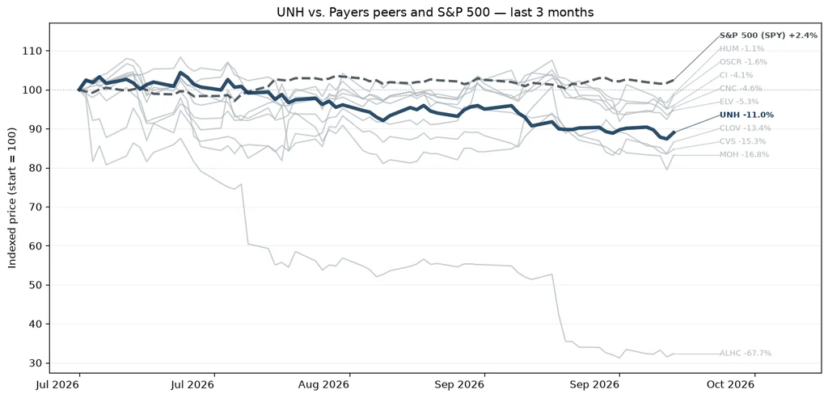

UnitedHealth Group is one of the largest private health insurers and provides medical benefits to about 51 million members globally, including 1 million outside the US as of December 2025. As a leader in employer-sponsored, self-directed, and government-backed insurance plans, UnitedHealth has obtained massive scale in medical insurance. Along with its insurance assets, UnitedHealth's Optum franchises help create a healthcare services colossus that spans everything from pharmaceutical benefits to providing outpatient care and analytics to affiliates and third parties.

### CVS Health (CVS)

*Payers · $135.1B · 3m -17.4% · 12m +11.6% · 24m +33.9%*

[Google Finance](https://www.google.com/finance/quote/CVS:NYSE?tab=earnings&hl=en)

Healthcare retail ecosystem.

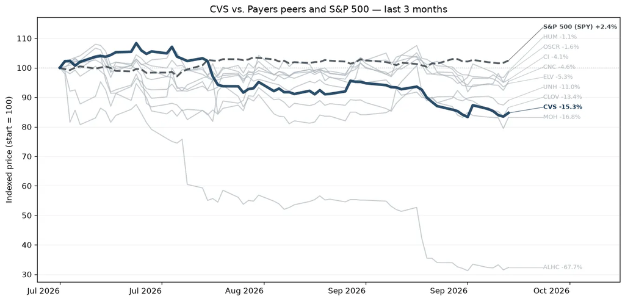

CVS Health offers a diverse set of healthcare services. Its roots are in its retail pharmacy operations, where it operates around 9,000 stores primarily in the US. CVS is also a large pharmacy benefit manager (acquired through Caremark), processing about 2 billion adjusted claims annually. It operates a top-tier health insurer (acquired through Aetna) through which it serves about 27 million medical members. The acquisition of Oak Street Health added primary care services to the mix, which could have significant synergies with all existing business lines.

### Humana (HUM)

*Payers · $43.7B · 3m -2.1% · 12m +36.9% · 24m +61.8%*

[Google Finance](https://www.google.com/finance/quote/HUM:NYSE?tab=earnings&hl=en)

Large payer, Medicare and Medicare Advantage focused.

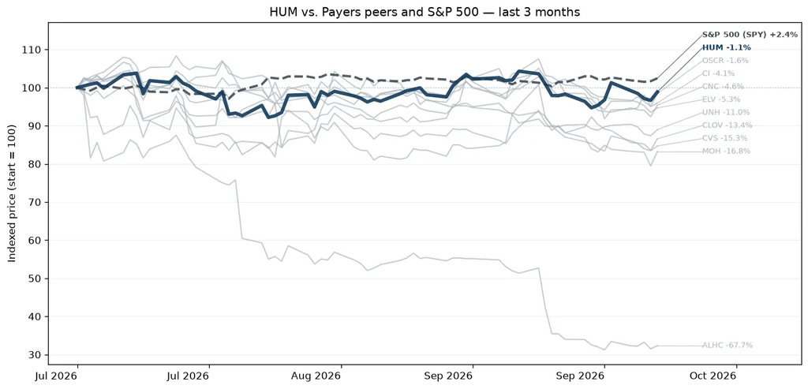

Humana is one of the largest private health insurers in the US, and the firm has built a niche specializing in government-sponsored programs, with nearly all its medical membership stemming from Medicare, Medicaid, and the military's Tricare program. Beyond medical insurance, the company provides other healthcare services, including primary-care services, at-home services, and pharmacy benefit management.

### Oscar Health (OSCR)

*Payers · $9.4B · 3m -3.9% · 12m +42.8% · 24m +53.6%*

[Google Finance](https://www.google.com/finance/quote/OSCR:NYSE?tab=earnings&hl=en)

Tech-focused payer with large exposure to exchange products and ICHRAs.

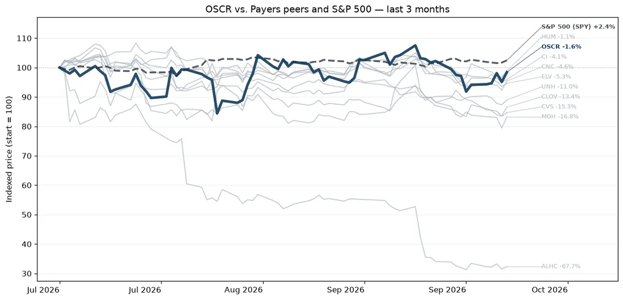

Oscar Health Inc is a healthcare technology company built around a full stack technology platform and a relentless focus on serving its members. It offers Individual & Family plans and health technology solutions that power the healthcare industry. Oscar operates as one segment to sell insurance to individuals, families and employees through the federal and state-run healthcare exchanges formed in conjunction with the Patient Protection and Affordable Care Act (ACA) and leverages its technology platform to provide services via its Oscar offering.

### Molina Healthcare (MOH)

*Payers · $10.2B · 3m -17.5% · 12m -6.2% · 24m -42.7%*

[Google Finance](https://www.google.com/finance/quote/MOH:NYSE?tab=earnings&hl=en)

Managed-care company providing health insurance through government programs.

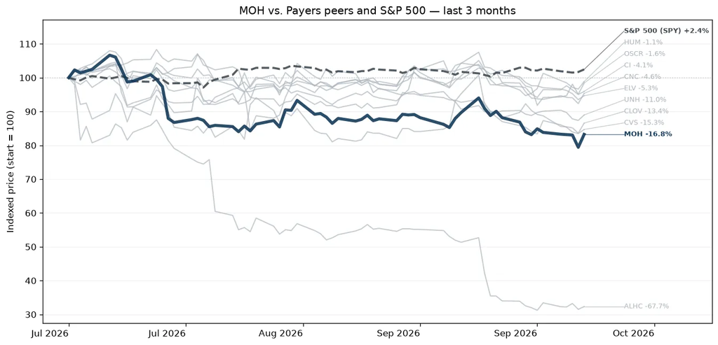

Molina Healthcare Inc provides medical insurance plans through Medicaid, the individual exchanges, and Medicare. The company operates in four reportable segments consisting of: 1) Medicaid; 2) Medicare; 3) Marketplace; and 4) Other. It manages health benefit risks for more than 5 million people, with more than 85% of those members coming through contracts with state governments for their Medicaid programs. Medicaid contracts in four states-California, New York, Texas, and Washington-account for over half of its enrollees.

### Cigna (CI)

*Payers · $73.7B · 3m -6.0% · 12m -13.0% · 24m -20.8%*

[Google Finance](https://www.google.com/finance/quote/CI:NYSE?tab=earnings&hl=en)

Employer-focused health insurance company.

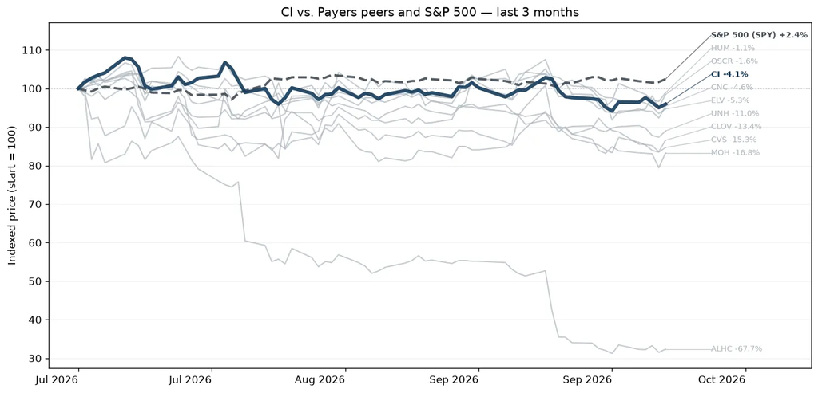

Cigna primarily provides pharmacy benefit management and health insurance services. Its PBM and specialty pharmacy services, which were greatly expanded by its 2018 merger with Express Scripts, are mostly sold to health insurance plans and employers. Its largest PBM contract is with the Department of Defense, and it recently won a multiyear deal with top-tier insurer Centene. In health insurance and other benefits, Cigna primarily serves employers through self-funding arrangements, and the company operates mostly in the US with 16 million US and 2 million international medical members covered as of December 2025.

### Elevance (ELV)

*Payers · $81.5B · 3m -7.5% · 12m +10.3% · 24m -21.5%*

[Google Finance](https://www.google.com/finance/quote/ELV:NYSE?tab=earnings&hl=en)

Health insurance company, previously named Anthem.

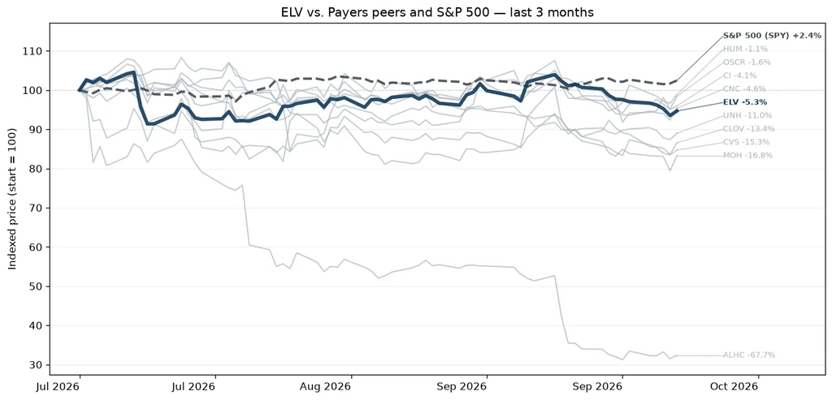

Elevance Health remains one of the leading health insurers in the US, providing medical benefits to 45 million medical members at the end of 2025. The company offers employer, individual, and government-sponsored coverage plans. Elevance differs from its peers in its unique position as the largest single provider of Blue Cross Blue Shield branded coverage, operating as the licensee for the Blue Cross Blue Shield Association in 14 states. Through acquisitions, such as the Amerigroup deal in 2012 and MMM in 2021, Elevance's reach expands beyond those states in government-sponsored programs, such as Medicaid and Medicare Advantage plans, too. It is also an emerging player in pharmacy benefit management and other healthcare services.

### Clover Health (CLOV)

*Payers · $2.2B · 3m -16.7% · 12m +69.1% · 24m +8.4%*

[Google Finance](https://www.google.com/finance/quote/CLOV:NASDAQ?tab=earnings&hl=en)

American healthcare company company providing Medicare Advantage insurance plans.

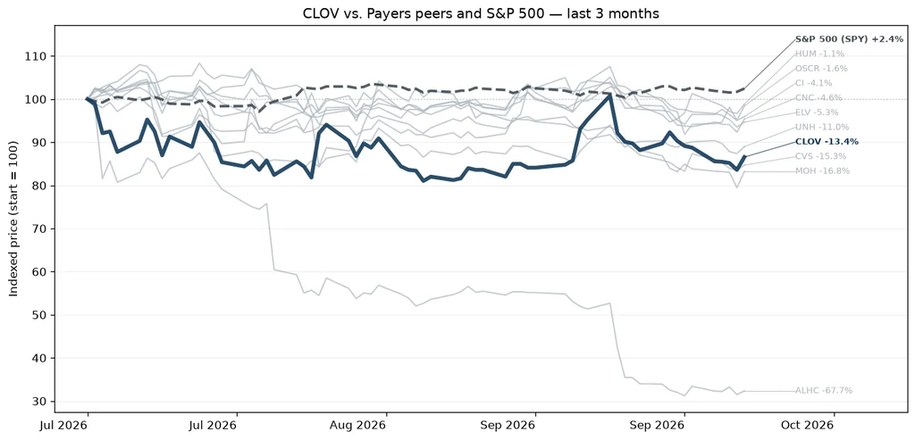

Clover Health Investments Corp is a healthcare technology company. It focuses on empowering Medicare physicians to proactively manage chronic diseases through its proprietary software platform, Clover Assistant. This cloud-based solution provides personalized insights to physicians, enabling early detection and management of chronic conditions. It operates in one segment: Insurance, through which it offers PPO and HMO plans to Medicare Advantage members in several states.

### Centene (CNC)

*Payers · $30.7B · 3m -7.2% · 12m +62.8% · 24m -12.6%*

[Google Finance](https://www.google.com/finance/quote/CNC:NYSE?tab=earnings&hl=en)

Health insurance for government and privately insured healthcare programs.

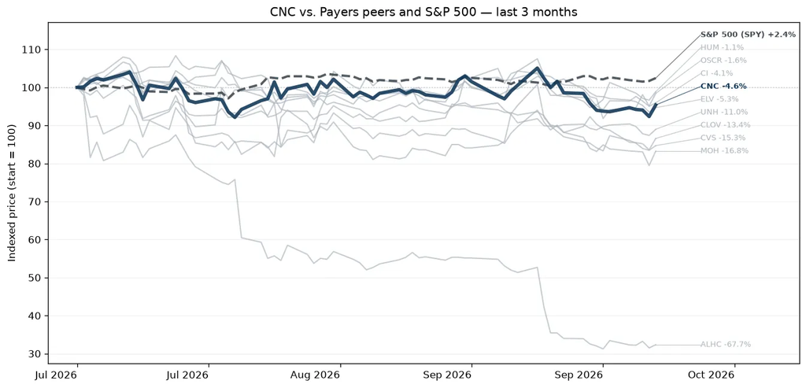

Centene is a managed care organization that focuses on government-sponsored healthcare plans, including Medicaid, Medicare, and the individual exchanges. Centene served 20 million medical members as of December 2025, mostly in Medicaid (about 64% of membership), the individual exchanges (about 28%), and Medicare (about 5%). The company also provides Medicare Part D pharmaceutical plans.

### Alignment Health (ALHC)

*Payers · $3.1B · 3m -66.6% · 12m -52.2% · 24m -27.3%*

[Google Finance](https://www.google.com/finance/quote/ALHC:NASDAQ?tab=earnings&hl=en)

Tech-enabled Medicare Advantage Company.

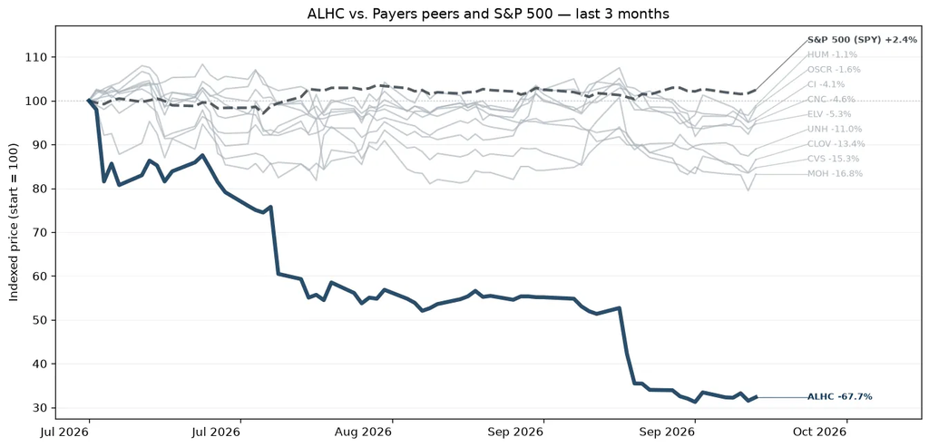

Alignment Healthcare Inc is a next-generation, consumer-centric platform that is revolutionizing the healthcare experience for seniors through Medicare Advantage plans. These plans are marketed and sold direct-to-consumer, allowing seniors to select the manner in which customers receive healthcare coverage and services on an annual basis. The company combines a technology platform and clinical model for more effective health outcomes.

### HCA Healthcare (HCA)

*Health System Providers · $87.2B · 3m +3.9% · 12m -0.7% · 24m +8.3%*

[Google Finance](https://www.google.com/finance/quote/HCA:NYSE?tab=earnings&hl=en)

Largest for-profit hospital and outpatient care operator in the United States.

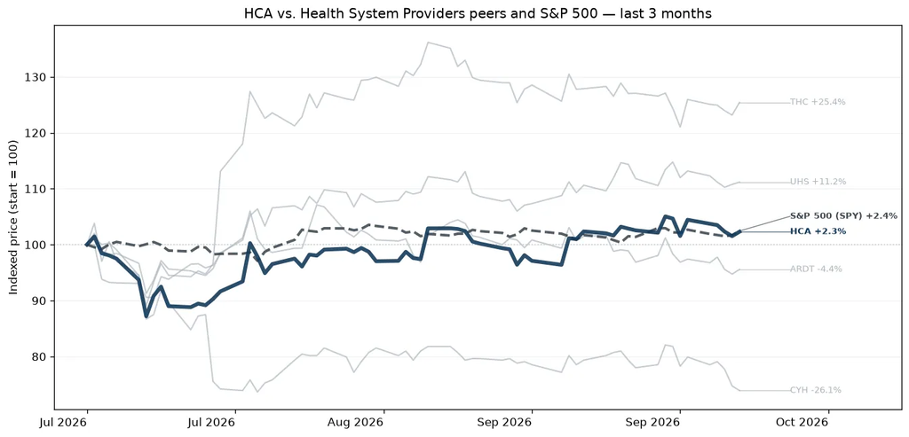

HCA Healthcare is a Nashville-based healthcare provider organization operating the largest collection of acute-care hospitals in the United States. As of December 2025, the firm owned and operated 190 hospitals and over 2,500 outpatient facillities across 19 states and a small foothold in the United Kingdom.

### Tenet Health (THC)

*Health System Providers · $20.5B · 3m +26.9% · 12m +27.4% · 24m +65.2%*

[Google Finance](https://www.google.com/finance/quote/THC:NYSE?tab=earnings&hl=en)

Diversified healthcare provider with hospitals and a leading ambulatory surgery center platform through USPI.

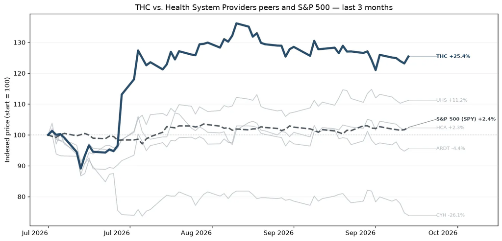

Tenet Healthcare is a Dallas-based healthcare services organization. It operates acute and specialty hospitals (50 as of December 2025) and hundreds of ambulatory surgery centers and other outpatient facilities across the US, primarily in the South. Through its Conifer segment, Tenet also provides revenue cycle management solutions.

### Universal Health Services (UHS)

*Health System Providers · $10.2B · 3m +11.0% · 12m -15.2% · 24m -18.5%*

[Google Finance](https://www.google.com/finance/quote/UHS:NYSE?tab=earnings&hl=en)

Hospital operator with significant acute care and behavioral health business.

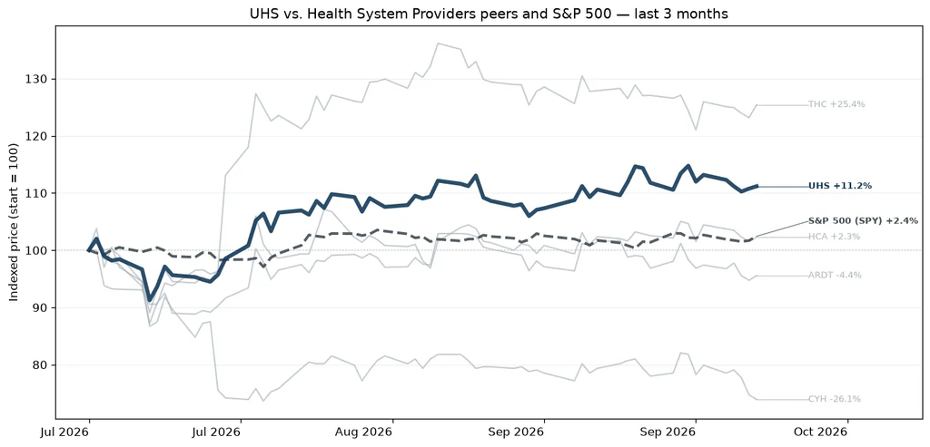

Universal Health Services Inc offers healthcare services through its behavioral health centers, acute care hospitals, and related outpatient facilities. As of late 2025, the company operated 346 inpatient behavioral health centers, 29 acute care hospitals, and many supportive outpatient facilities. Its operations are concentrated in the U.S, particularly in Nevada (21% of 2025 operating profits), Texas (19%), and California (13%), although it does have some exposure to the UK behavioral health market (6% of 2025 sales) too. While its acute care services account for over 55% of revenue, the behavioral health centers sport higher margins and account for over 55% of pretax profits.

### Community Health Systems (CYH)

[Google Finance](https://www.google.com/finance/quote/CYH:NYSE?tab=earnings&hl=en)

Operator of community hospitals primarily serving non-urban and regional markets.

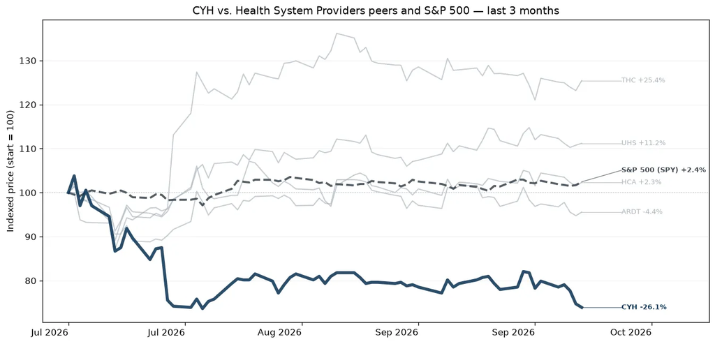

Community Health Systems Inc is a publicly owned hospital operator in the United States. The company also owns four home health agencies and provides management and consulting services to independent hospitals. The firm derives revenue through a broad range of general and specialized hospital healthcare services and outpatient services.

### Ardent Health Partners (ARDT)

*Health System Providers · $1.5B · 3m -3.9% · 12m -26.2% · 24m -42.5%*

[Google Finance](https://www.google.com/finance/quote/ARDT:NYSE?tab=earnings&hl=en)

Regional hospital operator focused on integrated health systems across mid-sized US markets.

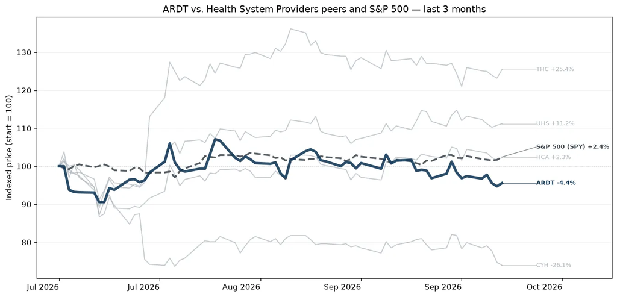

Ardent Health Inc is a provider of healthcare in growing mid-sized urban communities across the U.S and operating in eight growing mid-sized urban markets across six states Texas, Oklahoma, New Mexico, New Jersey, Idaho, and Kansas. The main focus on people and investments in services and technologies.

### The Ensign Group (ENSG)

*Inpatient Non-Acute Providers · $10.4B · 3m +2.1% · 12m -2.1% · 24m +19.1%*

[Google Finance](https://www.google.com/finance/quote/ENSG:NASDAQ?tab=earnings&hl=en)

Leading operator of skilled nursing facilities, rehabilitation centers, and senior-care services.

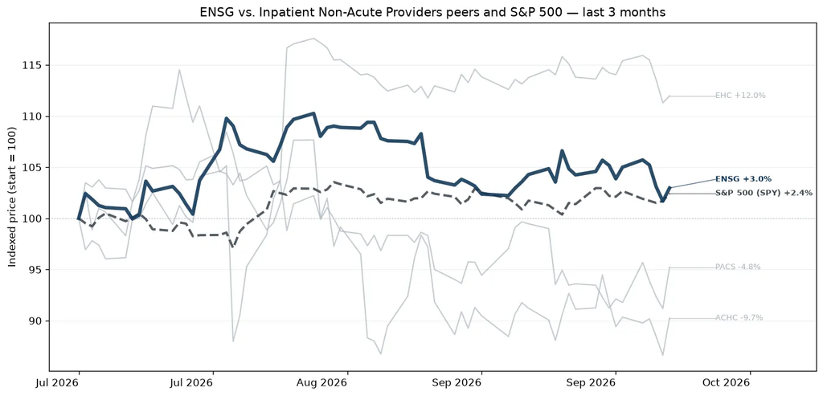

Ensign Group Inc provides post-acute healthcare services in the United States. Its regional subsidiaries oversee skilled nursing, assisted living, home health and hospice, mobile ancillary, and urgent care operations. Medicare and Medicaid programs contribute majority of revenue received for Ensign's services. The firm operates through two segments, Skilled services, and Standard Bearer. The skilled services segment includes the operation of skilled nursing facilities and rehabilitation therapy services. The Standard Bearer segment comprises of properties owned by the company through its captive REIT and leased to skilled nursing and assisted living operations. The majority of the revenue is generated from the skilled services segment.

### Acadia Healthcare (ACHC)

[Google Finance](https://www.google.com/finance/quote/ACHC:NASDAQ?tab=earnings&hl=en)

Largest provider of behavioral health and addiction treatment services.

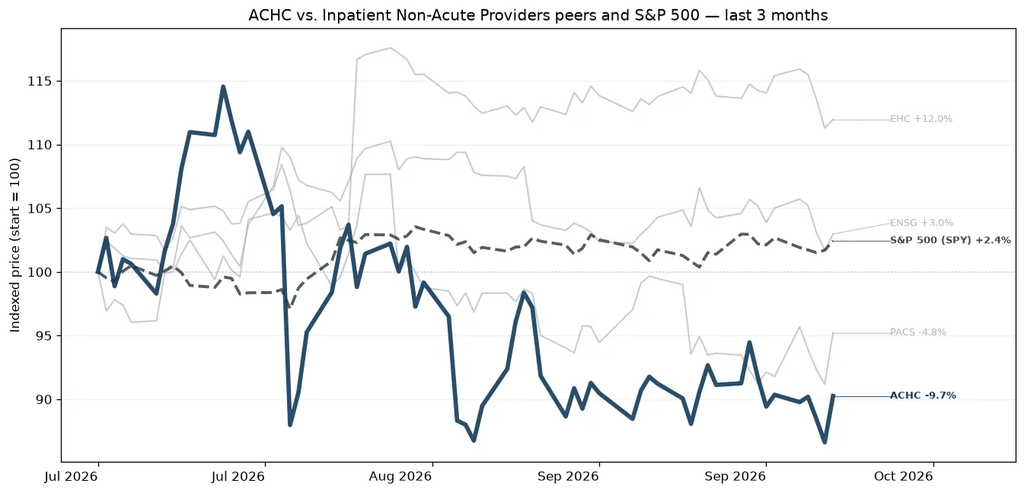

Acadia Healthcare Co Inc acquires and develops behavioral healthcare facilities. Its facilities and services are classified into the following categories: acute inpatient psychiatric facilities; specialty treatment facilities; CTCs; and residential treatment centers. In which Acute inpatient psychiatric facilities contribute the majority of revenue in the United States. The Company has one reportable segment, behavioral healthcare services. The behavioral healthcare services segment provides inpatient and outpatient behavioral healthcare services.

### Encompass Health (EHC)

*Inpatient Non-Acute Providers · $11.0B · 3m +12.5% · 12m -2.8% · 24m +26.8%*

[Google Finance](https://www.google.com/finance/quote/EHC:NYSE?tab=earnings&hl=en)

In-patient post-acute rehabilitation services.

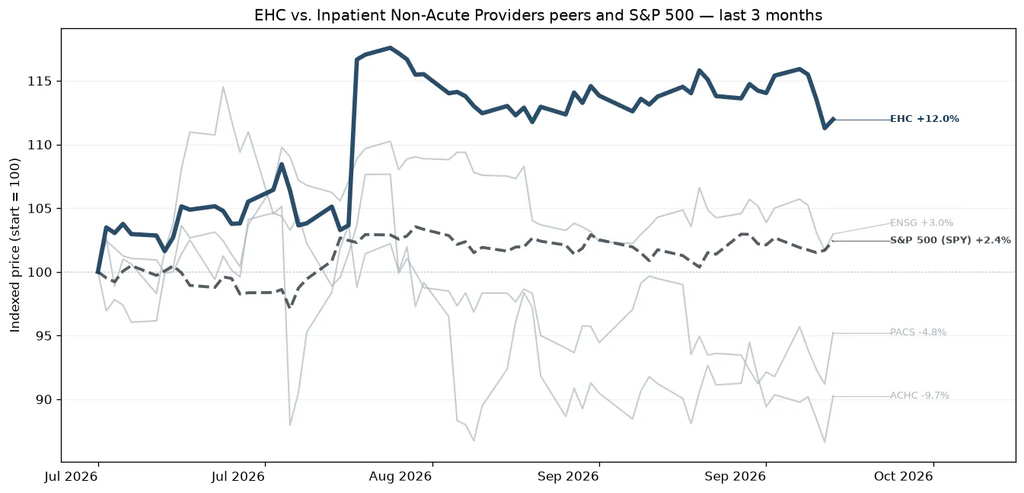

Encompass Health Corp provides post-acute healthcare services in the United States through a network of inpatient rehabilitation hospitals, which is the company's sole segment. Inpatient rehabilitation contributes the majority of the firm's revenue and provides specialized rehabilitative treatment through a network of inpatient hospitals. The company's inpatient rehabilitation hospitals provide a higher level of rehabilitative care to patients who are recovering from conditions such as stroke and other neurological disorders, cardiac and pulmonary conditions, brain and spinal cord injuries, complex orthopedic conditions, and amputations.

### PACS Group (PACS)

*Inpatient Non-Acute Providers · $7.3B · 3m -3.7% · 12m +213.0% · 24m +11.3%*

[Google Finance](https://www.google.com/finance/quote/PACS:NYSE?tab=earnings&hl=en)

Post-acute care and skilled nursing company.

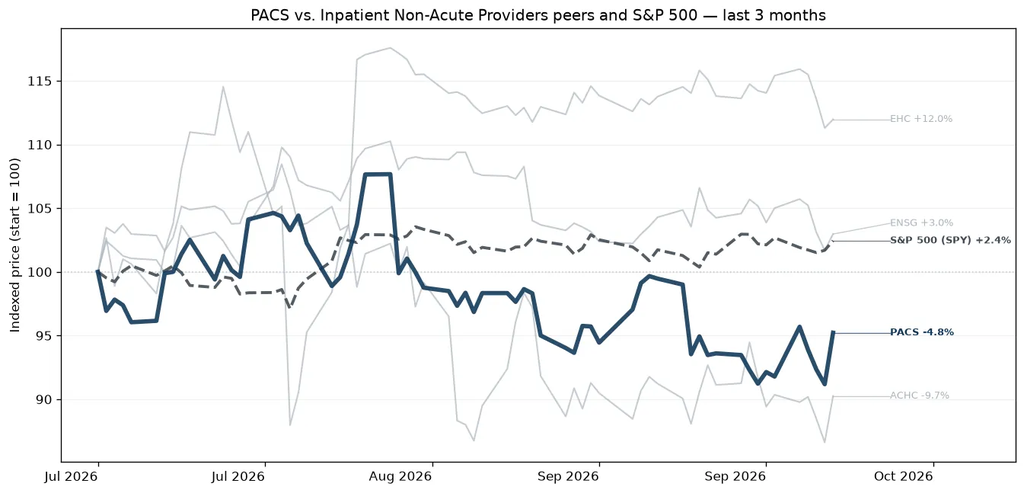

PACS Group Inc is a post-acute healthcare company mainly focused on delivering skilled nursing care through a portfolio of independently operated facilities. The post-acute care ecosystem serves individuals who need additional help recuperating from acute conditions, illnesses, or serious medical procedures after getting discharged from the hospital. It also provides senior care, assisted living, and independent living options in some of the communities. The company has one reportable segment.

### Healthpeak properties (DOC)

*Health Care Real Estate · $15.1B · 3m -11.0% · 12m +0.6% · 24m -11.9%*

[Google Finance](https://www.google.com/finance/quote/DOC:NYSE?tab=earnings&hl=en)

Healthcare industry real estate investment trust focused on outpatient medical offices, life science properties, an senior housing.

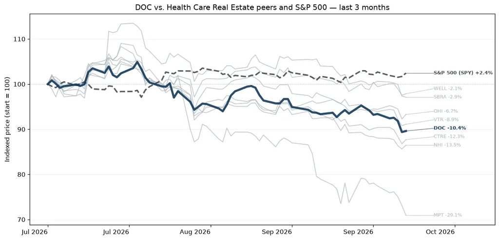

Healthpeak owns a diversified healthcare portfolio of approximately 700 in-place properties spread across mainly medical office and life science assets, plus a handful of senior housing, hospital, and skilled nursing/post-acute care assets, as well.

### Ventas, Inc (VTR)

*Health Care Real Estate · $48.0B · 3m -9.2% · 12m +20.4% · 24m +34.4%*

[Google Finance](https://www.google.com/finance/quote/VTR:NYSE?tab=earnings&hl=en)

Real estate investment trust focused on ownership and management of senior housing, research, medicine office buildings, and healthcare facilities.

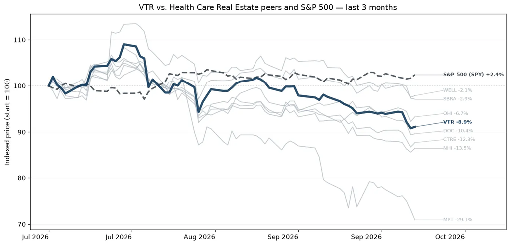

Ventas owns a diversified healthcare portfolio of almost 1,400 in-place properties spread across the senior housing, medical office, hospital, life science, and skilled nursing/post-acute care. The portfolio includes almost 100 properties in Canada and the United Kingdom as the company looks for additional investment opportunities in countries with mature healthcare systems that operate similarly to the United States. The firm also owns mortgages and other loans, contributing about 1% of net operating income.

### Medical Properties Trust (MPT)

*Health Care Real Estate · $2.8B · 3m -28.8% · 12m n/a · 24m n/a*

[Google Finance](https://www.google.com/finance/quote/MPT:NYSE?tab=earnings&hl=en)

Real estate investment trust for healthcare facilities in the US and Europe.

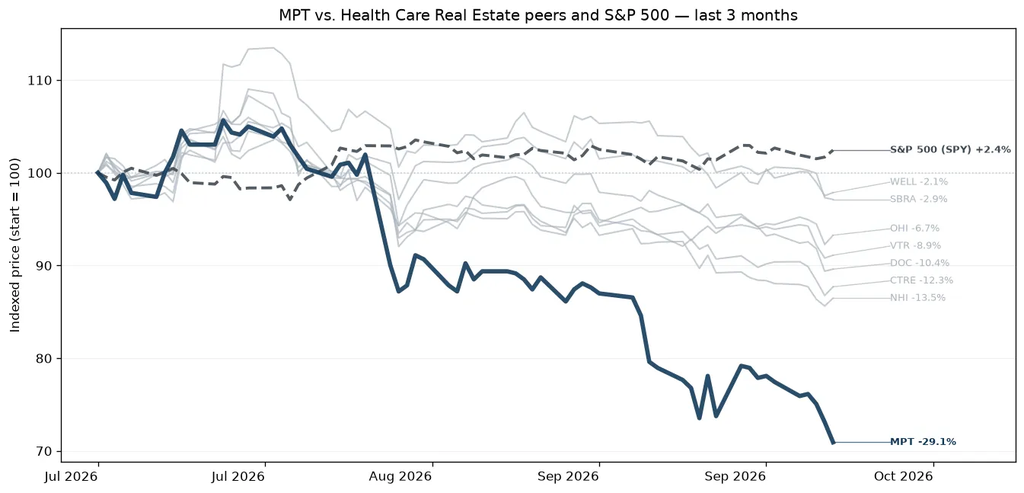

Medical Properties Trust Inc acquires and develops net-leased healthcare facilities. Its investments in healthcare real estate, other loans, and any investments in tenants are considered a single reportable segment. Its business strategy is to acquire and develop healthcare facilities and lease the facilities to healthcare operating companies under long-term net leases, which require the tenant to bear of the costs associated with the property. The group's geographic areas are the United States, the United Kingdom, and All other countries.

### National Health Investors (NHI)

*Health Care Real Estate · $3.7B · 3m -15.2% · 12m -16.3% · 24m -19.2%*

[Google Finance](https://www.google.com/finance/quote/NHI:NYSE?tab=earnings&hl=en)

Healthcare REIT focused on senior housing, skilled nursing, and long-term care properties.

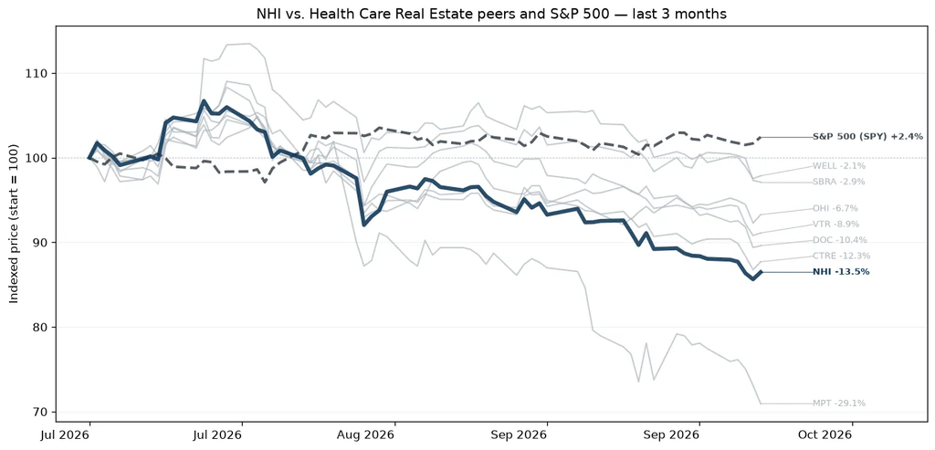

National Health Investors Inc is a self-managed REIT that owns, leases, operates, and finances the development of senior housing communities and medical facilities. It operates through two segments: Real Estate Investments and Senior Housing Operating Portfolio (SHOP). The Real Estate Investments segment, which generates the majority of revenue, includes real estate leases, mortgages, and other notes receivable related to independent living facilities, assisted living facilities, entrance fee communities, senior living campuses, skilled nursing facilities, and a hospital. The SHOP segment consists of ventures that own and operate independent living facilities. The company's revenues are derived from rental income, interest and other income, and resident fees and services.

### Omega Healthcare Investors (OHI)

*Health Care Real Estate · $15.1B · 3m -7.4% · 12m +11.1% · 24m +16.2%*

[Google Finance](https://www.google.com/finance/quote/OHI:NYSE?tab=earnings&hl=en)

Healthcare REIT healthcare REIT focused on skilled nursing and assisted living facilities.

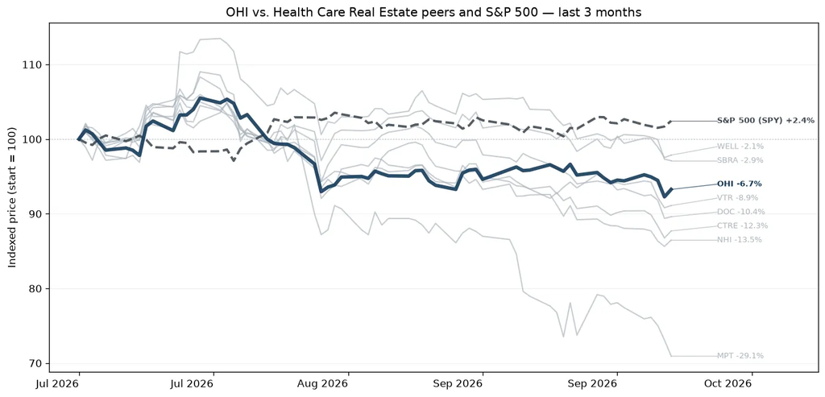

Omega Healthcare Investors Inc is a real estate investment trust that invests in healthcare-related real estate properties located in the United States (U.S.), the United Kingdom (U.K.), and Canada. The company's objective is to provide attractive returns to investors while serving as the preferred capital partner to its third-party healthcare operating companies and affiliates, as well as other third-party healthcare operators, allowing them to focus on delivering a high level of care to their resident patients. Omega's investment portfolio mainly consists of skilled nursing facilities, assisted living facilities (ALFs), including care homes in the U.K., independent living facilities, rehabilitation and acute care facilities, and continuing care retirement communities.

### Welltower (WELL)

*Health Care Real Estate · $166.9B · 3m -3.5% · 12m +30.1% · 24m +81.4%*

[Google Finance](https://www.google.com/finance/quote/WELL:NYSE?tab=earnings&hl=en)

Largest healthcare REIT, focused on senior housing, outpatient medical, and wellness-oriented healthcare properties.

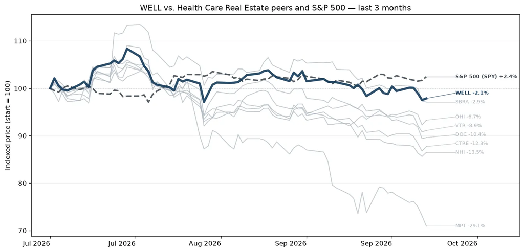

Welltower owns a diversified healthcare portfolio of 2,800 in-place properties spread across the senior housing, medical office, and skilled nursing/postacute care sectors. The portfolio includes over 900 properties in Canada and the United Kingdom as the company looks for additional investment opportunities in countries with mature healthcare systems that operate similarly to that of the United States.

### CareTrust REIT (CTRE)

*Health Care Real Estate · $9.6B · 3m -13.1% · 12m +2.3% · 24m +19.5%*

[Google Finance](https://www.google.com/finance/quote/CTRE:NYSE?tab=earnings&hl=en)

Healthcare REIT focused on skilled nursing, senior housing, and other post-acute care facilities.

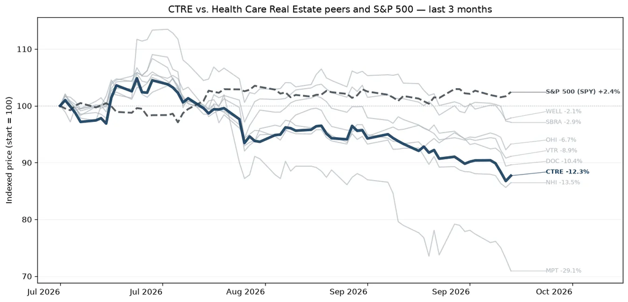

CareTrust REIT Inc is a self-administered, publicly traded REIT engaged in the ownership, acquisition, financing, development, and leasing of skilled nursing, seniors housing, and other healthcare-related properties. The company has one reportable segment consisting of investments in healthcare-related real estate assets. It generates revenues by leasing healthcare-related properties to healthcare operators under triple-net lease arrangements, in which the tenant is solely responsible for property-related costs. The company operates in Domestic and Foreign markets, with the majority of revenue coming from Domestic operations.

### Sabra Health Care REIT (SBRA)

[Google Finance](https://www.google.com/finance/quote/SBRA:NASDAQ?tab=earnings&hl=en)

healthcare REIT focused on skilled nursing, senior housing, and behavioral health properties.

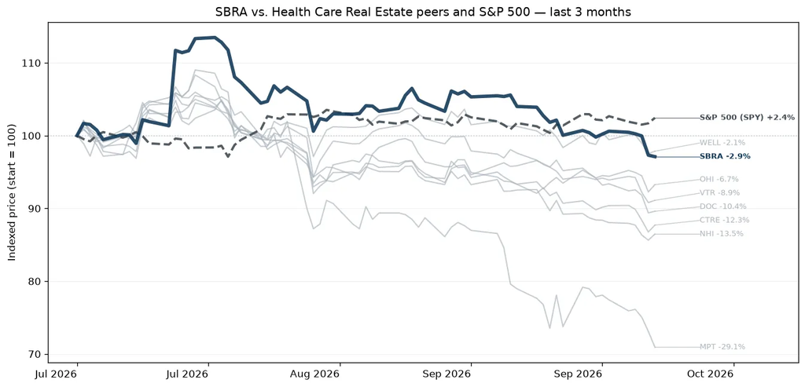

Sabra Health Care REIT Inc is a healthcare facility real estate investment trust. The company operates one segment that owns and invests in healthcare real estate. All of the company's revenue is generated in the United States. Sabra's operations consist of nursing facilities, assisted living centers, and mental health facilities.

### Privia Health Group (PRVA)

*Value-Based Care · $3.0B · 3m -25.8% · 12m -15.7% · 24m +15.4%*

[Google Finance](https://www.google.com/finance/quote/PRVA:NASDAQ?tab=earnings&hl=en)

Value-based care company focusing on physician enablement for independent practices.

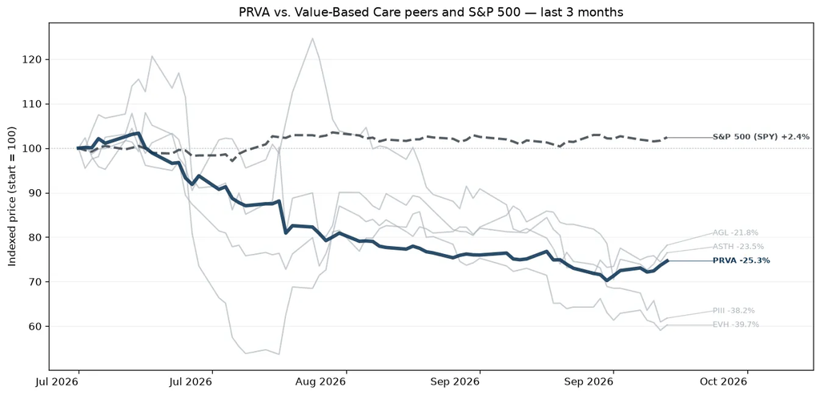

Privia Health Group Inc is one of the physician enablement companies in the United States with a presence in around 24 states and the District of Columbia. The group builds scaled provider networks with primary-care centric medical groups, risk-bearing entities, a physician-led governance structure, and the Privia Platform comprising an extensive suite of technology and service solutions. It collaborates with medical groups, health plans, and health systems to optimize approximately 1,300+ physician practices, improve the patient experience for over 5.8+ million patients, and reward around 5,300+ physicians and practitioners for delivering high-value care.

### Astrana Health (ASTH)

[Google Finance](https://www.google.com/finance/quote/ASTH:NASDAQ?tab=earnings&hl=en)

Physician centric management company that operates and coordinates provider networks to take on risk contracts.

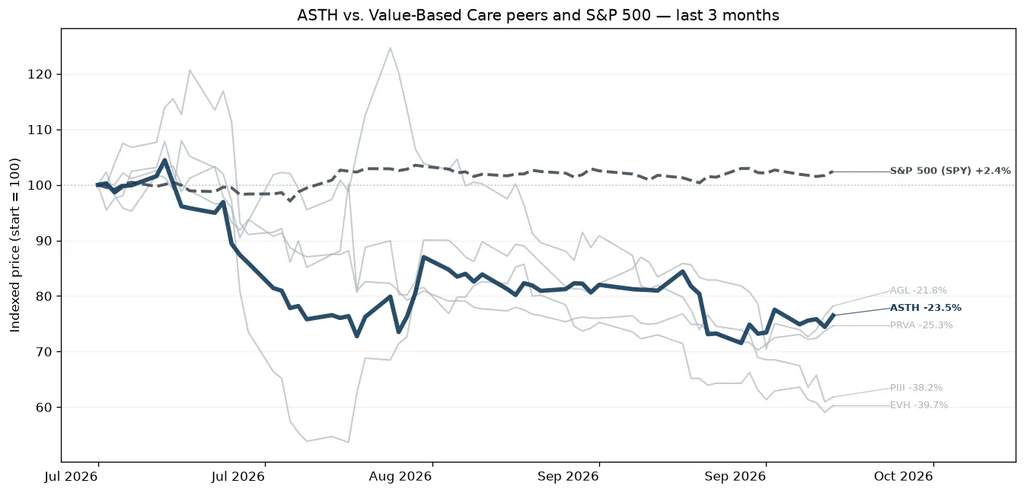

Astrana Health Inc is a patient-centered, physician-centric integrated population health management company. The company is working to provide coordinated, outcomes-based medical care cost-effectively. It is focused on physicians providing high-quality medical care, population health management, and care coordination for patients, particularly senior patients and patients with multiple chronic conditions. The company's three reportable segments are Care Partners, Care Delivery, and Care Enablement. It generates the majority of its revenue from the Care Partners segment.